# Dwell Time Analysis

redminers

November 15, 2015

This R Analysis, loads the data directly from the tables at MySQL server hosted at UITS, IU.

Creating an connection, Lets check the average dwell time per stop across all routes,

```r
library(RMySQL)
```

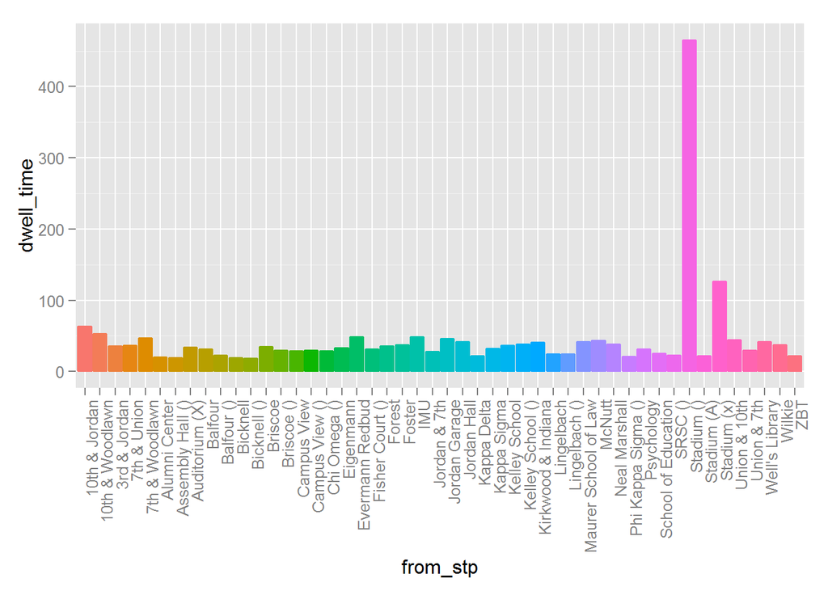

```r
library(ggplot2)
mydb = dbConnect(MySQL(), user='bususer', password='Password123', dbname='iubus', host='rdc04.uits.iu.edu',port=3099)
rs = dbSendQuery(mydb, "select from_stp,avg(dwell_time) 'dwell_time' from route_run_temp where dwell_time <> 0 group by from_stp order by dwell_time")
data = fetch(rs, n=-1)
ggplot(data,aes(x=from_stp,y=dwell_time,color=from_stp,fill=from_stp))+stat_summary(fun.y="mean",geom="bar")+theme(axis.text.x = element_text(angle = 90, hjust = 1),legend.position="none")
```

Lets dig in a little Deep, lets see dwell time across routes,

```r
rs = dbSendQuery(mydb, "select from_stp,avg(dwell_time) 'dwell_time',route_id from route_run_temp where dwell_time <> 0 group by from_stp,route_id order by route_id")
```

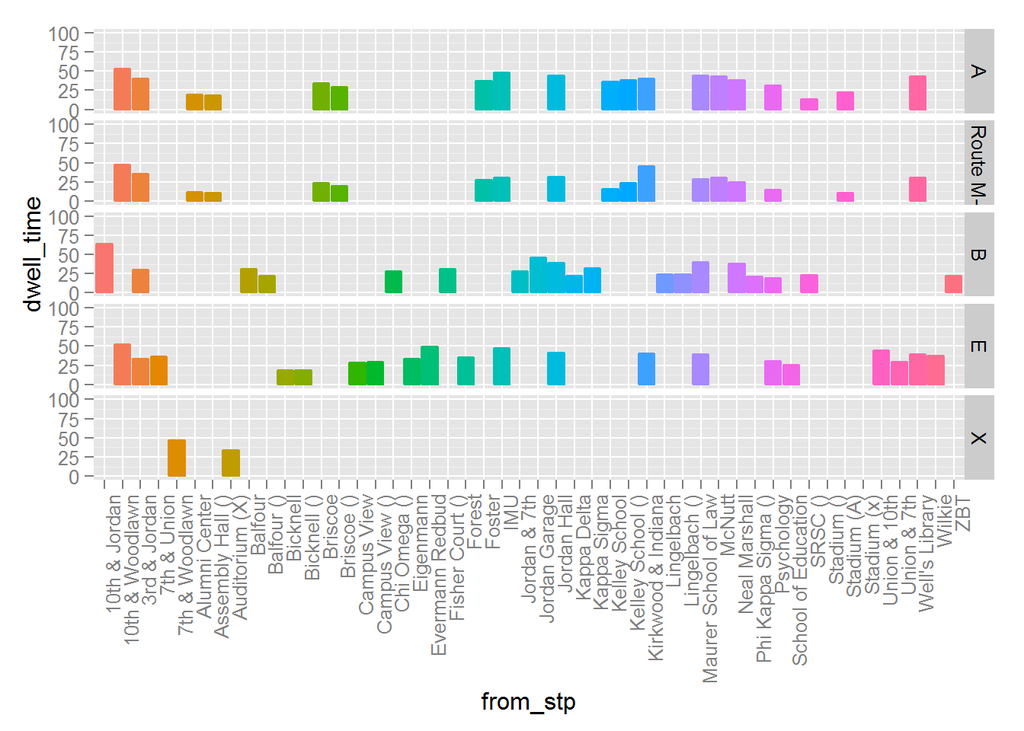

```r
data = fetch(rs, n=-1)
ggplot(data,aes(x=from_stp,y=dwell_time,color=from_stp,fill=from_stp))+ylim(0,100)+facet_grid(route_id~.)+stat_summary(fun.y="mean",geom="bar")+theme(axis.text.x = element_text(angle = 90, hjust = 1),legend.position="none")
```

Now lets see the Travel time between the stops for different routes, Assuming the directionality is specified as column titles.

```
##                 from_stp               to_stp  travel_time    route_id
## 1         Atwater Garage           Stadium ()   64234.2000           A
## 2         Well's Library        Neal Marshall     171.3617           A
## 3        Fisher Court ()           Stadium ()  136782.2676           A
## 4                Briscoe               McNutt      52.2570           A
## 5                 Foster           Briscoe ()      57.9496           A
## 6             Stadium ()          Stadium (A)    2669.5765           A
## 7        10th & Woodlawn           Psychology      75.9524           A
## 8            Evermann ()           Stadium ()  158770.4000           A
## 9   Maurer School of Law   Kirkwood & Indiana     264.1023           A
## 10         Jackson Creek           Stadium ()  516669.6667           A
## 11            Auditorium           Stadium ()   94903.8889           A
## 12         Neal Marshall         3rd & Jordan     115.7905           A
## 13        Poplars Garage           Stadium ()   35615.6000           A
## 14                McNutt        Kelley School      66.2292           A
```

[output cut: 132 more lines]

First impression is that there are few junk values. There are stops which have high travelling time like 7 days, which is not possible. There are few acceptable valid values like IMU and Informatics takes about 2 minutes, which is true in real case also.